# Exemple de simulation pour explorer la prédiction génomique

Timothée Flutre (INRAE), Charlotte Brault

17/02/2020

Abstract

Ce document a pour but de montrer un exemple de prédiction génomique à partir de données simulées.

# 1 Contexte

Ce document fait partie de l’atelier “Prédiction Génomique” organisé et animé par Jacques David et Timothée Flutre depuis 2015, avec l’aide de Julie Fiévet et Philippe Brabant, à [Montpellier SupAgro](http://www.supagro.fr) dans le cadre de l’option [APIMET](http://www.agro-montpellier.fr/web/pages/?idl=19&page=216&id_page=630) (Amélioration des Plantes et Ingénierie végétale Méditerranéennes et Tropicales) couplée à la spécialité SEPMET (Semences Et Plants Méditerranéens Et Tropicaux) du [Master 3A](http://www.supagro.fr/web/pages/?idl=19&page=1689) (Agronomie et Agroalimentaire), et de la spécialisation [PIST](http://www.agroparistech.fr/Production-et-innovation-dans-les,1633.html) du [Cursus Ingénieur](http://www.agroparistech.fr/Cursus-ingenieurs.html) d’[AgroparisTech](http://www.agroparistech.fr/).

Le copyright appartient à Montpellier SupAgro et à l’Institut National de la Recherche Agronomique. Le contenu du répertoire est sous license [Creative Commons Attribution-ShareAlike 4.0 International](http://creativecommons.org/licenses/by-sa/4.0/). Veuillez en prendre connaissance et vous y conformer (contactez les auteurs en cas de doute).

Les versions du contenu sont gérées avec le logiciel git, et le dépôt central est hébergé sur [GitHub](https://github.com/timflutre/atelier-prediction-genomique).

Il est recommandé d’avoir déjà lu attentivement les documents “Premiers pas” et “Prédiction génomique” de l’atelier.

```r
suppressPackageStartupMessages(library(rrBLUP))
suppressPackageStartupMessages(library(cvTools))
```

Un certain niveau de déséquilibre de liaison entre génotypes aux SNP est indispensable pour obtenir une précision de prédiction suffisamment élevée en validation croisée. Pour cela, on peut utiliser le processus du coalescent avec recombinaison. Une bonne approximation de celui-ci est implémenté dans le paquet scrm. Par ailleurs, afin de tracer le déséquilibre de liaison en fonction de la distance physique, il vous faut aussi le paquet GenomicRanges de Bioconductor. Afin de faciliter l’utilisation de ces paquets dans ce document, il vous faut aussi avoir mon paquet de travail, rutilstimflutre, disponible sur GitHub.

```r
suppressPackageStartupMessages(library(scrm))
suppressPackageStartupMessages(library(GenomicRanges))
suppressPackageStartupMessages(library(rutilstimflutre))
suppressPackageStartupMessages(library(adegenet))
```

Il est également utile de savoir combien de temps est nécessaire pour exécuter tout le code R de ce document (voir l’annexe):

```r
t0 <- proc.time()
```

# 2 Modèle

En se limitant à une architecture additive infinitésimale:

$$\begin{align*}
\boldsymbol{y} &= \boldsymbol{1} \, \mu + X \, \boldsymbol{\beta} + \boldsymbol{\epsilon} \\
&= \boldsymbol{1} \, \mu + \boldsymbol{a} + \boldsymbol{\epsilon}
\end{align*}$$

avec:

- $\boldsymbol{\epsilon} \sim \mathcal{N}_N(\boldsymbol{0}, \sigma^2 \, \text{Id})$;
- $\boldsymbol{\beta} \sim \mathcal{N}_P(\boldsymbol{0}, \sigma_\beta^2 \, \text{Id})$;
- $\boldsymbol{a} \sim \mathcal{N}_N(\boldsymbol{0}, \sigma_a^2 \, A_{\text{mark}})$ avec $A_{\text{mark}} = \frac{X X^T}{2 \sum_{p} f_p (1 - f_p)}$.

Cet estimateur de $A_{\text{mark}}$ est décrit dans [Habier et coll. (2007)](http://dx.doi.org/10.1534/genetics.107.081190), mais un meilleur estimateur, centré, est proposé dans [VanRaden (2008)](http://dx.doi.org/10.3168/jds.2007-0980): pour plus de détails, lire [Toro et coll. (2011)](http://www.gsejournal.org/content/43/1/27) et [Vitezica et coll. (2013)](http://dx.doi.org/10.1534/genetics.113.155176).

# 3 Simulation des données

```r
set.seed(111)
```

## 3.1 Paramètres de simulation

```r
is.infinitesimal <- TRUE
is.structure <- TRUE

nb.genos <- 300
Ne <- 10^4
chrom.len <- 10^5
mu <- 10^(-8)
c.rec <- 10^(-8)
nb.pops <- 10
```

## 3.2 Effets additifs des SNP

```r
if(is.infinitesimal){
  # Modèle infinitésimal : chaque marqueur a un effet faible sur le phénotype
  P <- 5000         # number of SNPs
  sigma.beta2 <- 10^(-3) # chosen arbitrarily
  beta <- rnorm(n=P, mean=0, sd=sqrt(sigma.beta2)) # effet du marqueur, tiré dans une loi normale
} else {
  # Simulation avec certains marqueurs à effet nuls et certains à effet non nul (QTL).
  nb_QTL <- 10
  QTL <- sample(P, nb_QTL) # échantillonnage des marqueurs à effet non nul (QTL)
  beta <- rep(0, P) # effet associé au marqueur nul ...
  beta[QTL] <- rnorm(n=nb_QTL, mean=0, sd=sqrt(sigma.beta2)) # sauf pour les QTL
}
```

Pour simuler une structure, on peut utiliser une fonction de Timothée Flutre (rutilstimflutre) : `SimulCoalescent`.

Voici un exemple de code pour appliquer cette fonction, disponible sur [Github](https://github.com/timflutre/rutilstimflutre/blob/master/misc/simul-pop-struct.Rmd)

## 3.3 Génotypes aux SNP

### 3.3.1 Coalescent séquentiel avec recombinaison **sans** structure

```r
set.seed(1234)

genomes.nostruct <- simulCoalescent(nb.inds=nb.genos, nb.reps=10,
                                    pop.mut.rate=4 * Ne * mu * chrom.len,
                                    pop.recomb.rate=4 * Ne * c.rec * chrom.len,
                                    chrom.len=chrom.len,
                                    nb.pops=nb.pops,
                                    verbose=1)
```

```
## simulate according to the SCRM ...
## scrm 600 10 -t 40 -r 40 1e+05 -I 10 60 60 60 60 60 60 60 60 60 60 5 -SC abs -oSFS
## nb of SNPs: 30810
##  chr1  chr2  chr3  chr4  chr5  chr6  chr7  chr8  chr9 chr10
##  3305  3149  3079  2915  2945  2943  3066  3259  3069  3080
## make a data.frame with SNP coordinates ...
## randomize haplotypes to make diploid genotypes ...
## convert haplotypes into genotypes encoded as allele dose ...
## permute alleles in haplotypes ...
## permute alleles in genotypes ...
```

```r
dim(genomes.nostruct$genos)
```

```
## [1]   300 30810
```

```r
genomes.nostruct$genos[1:8,1:8]
```

```
##        snp00001 snp00002 snp00003 snp00004 snp00005 snp00006 snp00007 snp00008
## ind001        2        2        0        0        2        0        2        2
## ind002        2        2        0        2        0        0        2        2
## ind003        2        2        0        2        0        0        2        2
## ind004        2        2        0        2        0        0        2        2
## ind005        2        2        0        2        0        0        2        2
## ind006        2        2        0        1        1        0        2        2
## ind007        2        2        0        1        0        0        2        2
## ind008        2        2        0        1        1        0        2        2
```

### 3.3.2 Coalescent séquentiel avec recombinaison et **avec** structure

La structure est ici simulée avec des taux de migration : plus le taux de migration est faible, plus les populations seront différenciées entre elles.

```r
if(is.structure){
  mig.rates <- c("high"=10^2, "med"=10,   "low"=0.5)
  genomes.struct <- list()
  for(i in seq_along(mig.rates)){
    set.seed(1234)
    genomes.struct[[names(mig.rates)[i]]] <- simulCoalescent(nb.inds=nb.genos, nb.reps=5,
                                                             pop.mut.rate=4 * Ne * mu * 10^5,
                                                             pop.recomb.rate=4 * Ne * c.rec * 10^5,
                                                             chrom.len=10^5,
                                                             nb.pops=nb.pops, mig.rate=mig.rates[i],
                                                             verbose=1)
  }
  sapply(genomes.struct, function(x){dim(x$genos)})
  genomes.struct$high$genos[1:8,1:8]
  genomes.struct$med$genos[1:8,1:8]
  genomes.struct$low$genos[1:8,1:8]
}
```

```
## simulate according to the SCRM ...
## scrm 600 5 -t 40 -r 40 1e+05 -I 10 60 60 60 60 60 60 60 60 60 60 100 -SC abs -oSFS
## nb of SNPs: 14560
## chr1 chr2 chr3 chr4 chr5
## 2820 3023 3012 2721 2984
## make a data.frame with SNP coordinates ...
## randomize haplotypes to make diploid genotypes ...
## convert haplotypes into genotypes encoded as allele dose ...
## permute alleles in haplotypes ...
## permute alleles in genotypes ...
## simulate according to the SCRM ...
## scrm 600 5 -t 40 -r 40 1e+05 -I 10 60 60 60 60 60 60 60 60 60 60 10 -SC abs -oSFS
## nb of SNPs: 14963
## chr1 chr2 chr3 chr4 chr5
## 2749 3157 3099 2861 3097
## make a data.frame with SNP coordinates ...
## randomize haplotypes to make diploid genotypes ...
## convert haplotypes into genotypes encoded as allele dose ...
## permute alleles in haplotypes ...
## permute alleles in genotypes ...
## simulate according to the SCRM ...
## scrm 600 5 -t 40 -r 40 1e+05 -I 10 60 60 60 60 60 60 60 60 60 60 0.5 -SC abs -oSFS
## nb of SNPs: 24673
## chr1 chr2 chr3 chr4 chr5
## 4886 4834 4952 4988 5013
## make a data.frame with SNP coordinates ...
## randomize haplotypes to make diploid genotypes ...
## convert haplotypes into genotypes encoded as allele dose ...
## permute alleles in haplotypes ...
## permute alleles in genotypes ...
```

```
##        snp00001 snp00002 snp00003 snp00004 snp00005 snp00006 snp00007 snp00008
## ind001        0        0        2        2        2        0        2        0
## ind002        0        0        2        2        2        0        2        0
## ind003        0        0        2        2        2        0        2        0
## ind004        0        0        2        2        2        0        2        0
## ind005        0        0        2        2        2        0        2        0
## ind006        0        0        2        2        2        0        2        0
## ind007        0        0        2        2        2        0        2        0
## ind008        0        0        2        2        2        0        2        0
```

#### 3.3.2.1 Visualisation de la structure

Combiner les simulations issues des 3 taux de migration dans une seule liste.

```r
if(is.structure){
  X.pops <- lapply(names(mig.rates), function(n){
    tmp <- genomes.struct[[n]]$genos
    nb.remain.chrs <- 10 - length(unique(genomes.struct[[n]]$snp.coords[colnames(tmp),"chr"]))
    remain.chrs <- unique(genomes.nostruct$snp.coords[,"chr"])[1:nb.remain.chrs]
    snps.toadd <- rownames(genomes.nostruct$snp.coords[genomes.nostruct$snp.coords$chr %in%
                                                         remain.chrs,])
    X <- cbind(tmp, genomes.nostruct$genos[, snps.toadd])
    colnames(X)[(ncol(tmp)+1):ncol(X)] <- paste0(colnames(X)[(ncol(tmp)+1):ncol(X)],
                                                 "_nostruct")
    X
  })
  names(X.pops) <- names(mig.rates)
  sapply(X.pops, dim)
}
```

```
##       high   med   low
## [1,]   300   300   300
## [2,] 29953 30356 40066
```

On a ici créé une liste qui contient (dans une liste imbriquée) les génotypes pour chaque taux de migration appliqué. Par la suite, on considérera que la population avec un fort taux de migration correspond à une population sans structure.

Représentation graphique de la structure

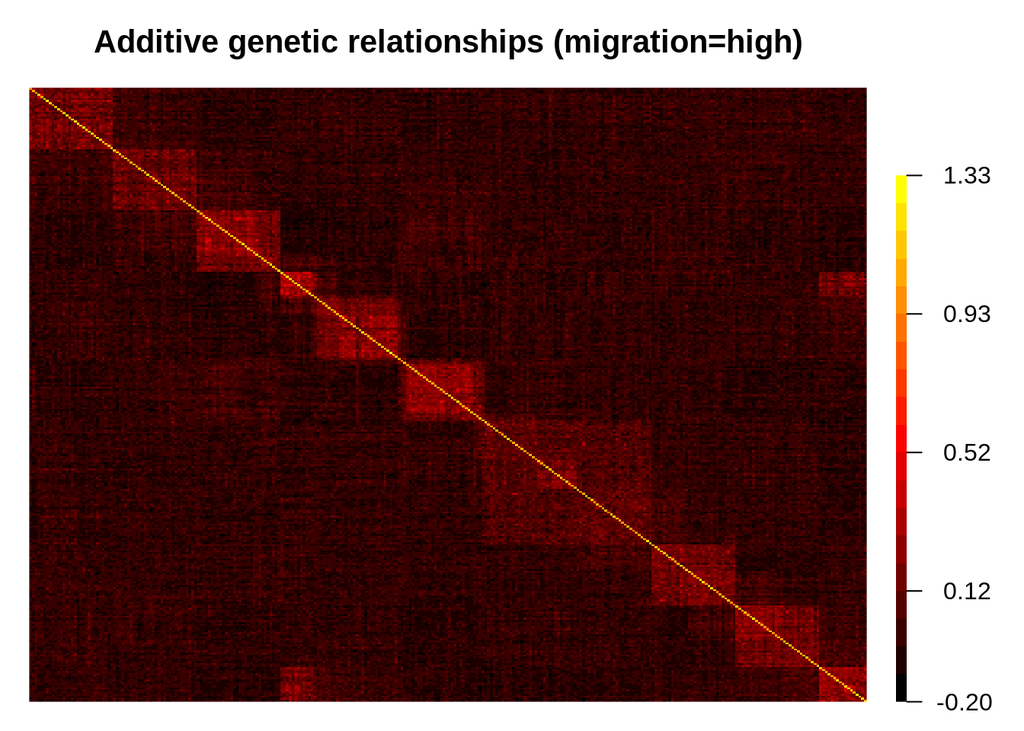

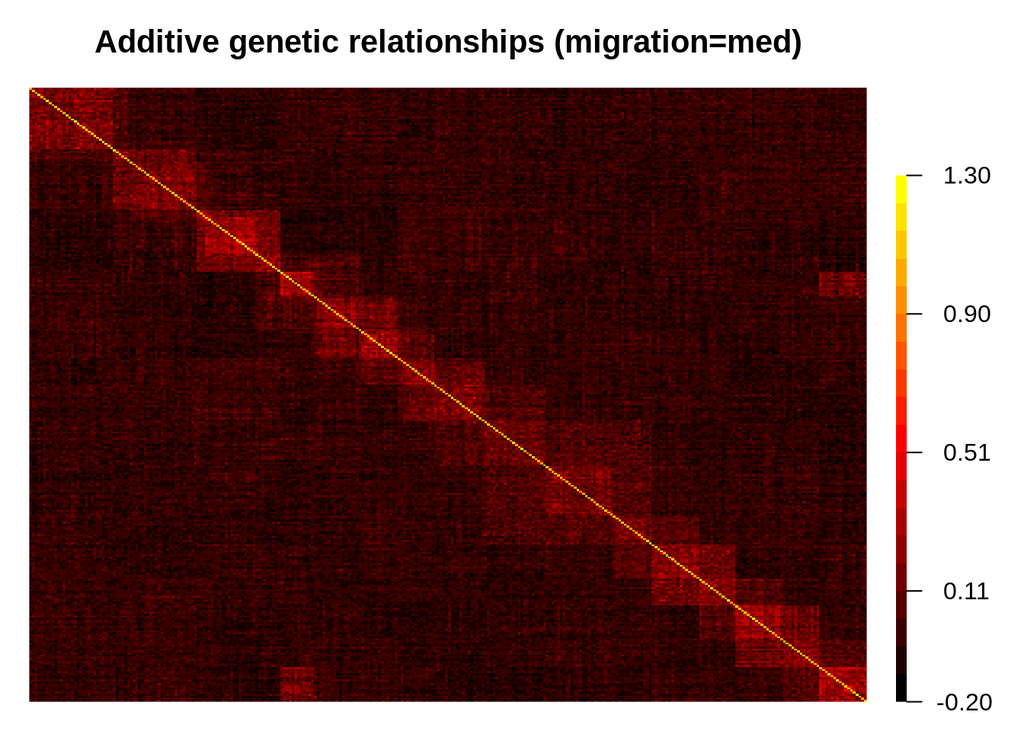

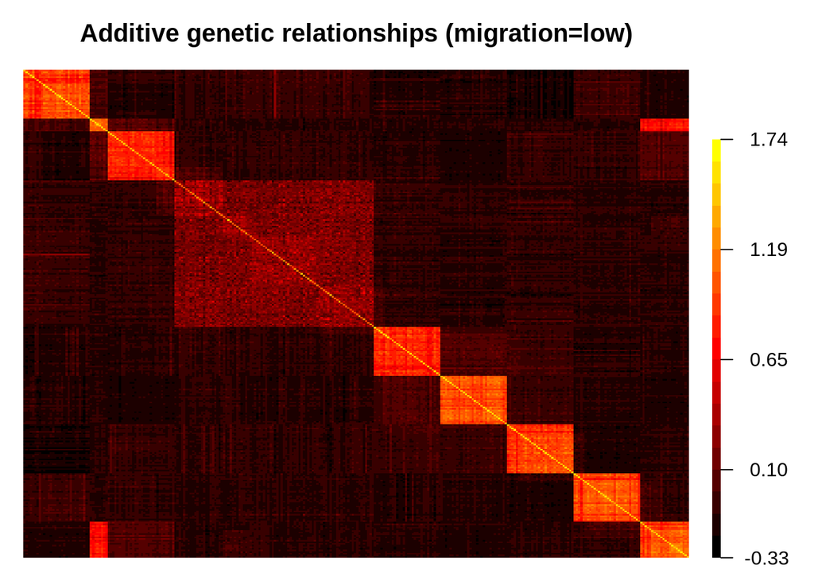

```r
if(is.structure){
  tmp <- lapply(names(X.pops), function(n){
    A <- estimGenRel(X=X.pops[[n]], verbose=0)
    imageWithScale(A, main=paste0("Additive genetic relationships (migration=", n, ")"))
  })
}
```

Affichage des groupes de structure génétique avec une **Analyse en Composantes Principales**.

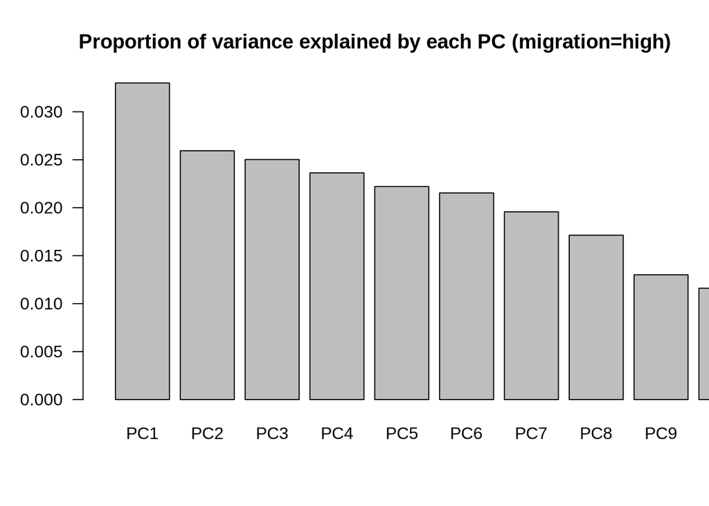

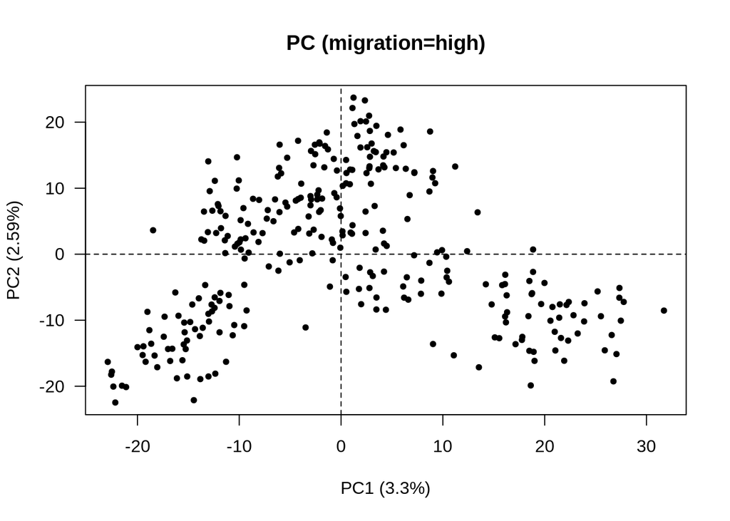

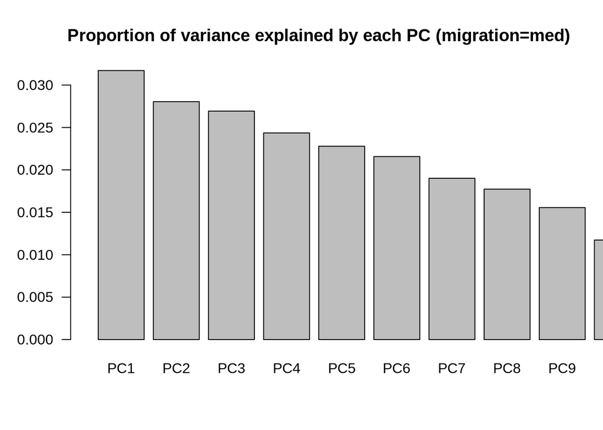

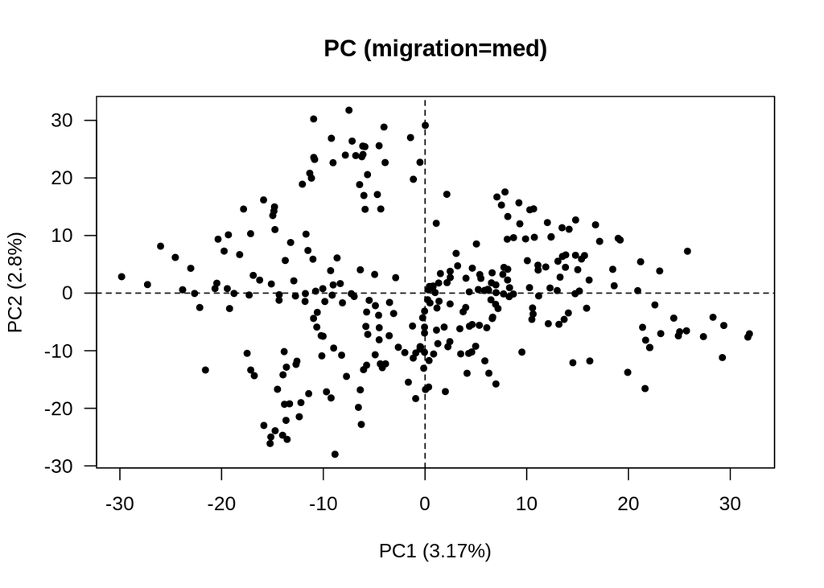

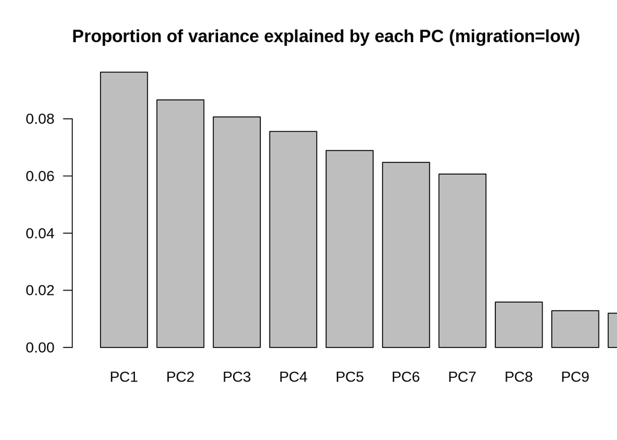

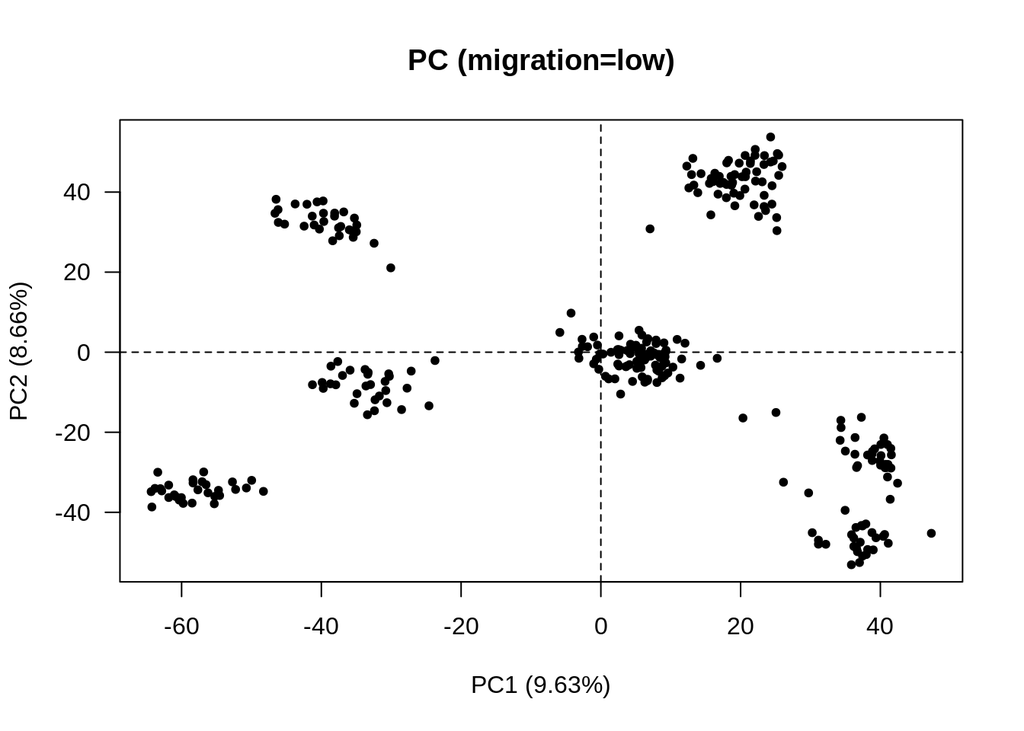

```r
if(is.structure){
  out.pca <- lapply(X.pops, function(X){
    pca(X=X)
  })
  sapply(out.pca, function(x){x$prop.vars[1:4]})
  tmp <- lapply(names(out.pca), function(x){
    barplot(out.pca[[x]]$prop.vars,
            main=paste0("Proportion of variance explained by each PC (migration=", x, ")"),
            xlim=c(0,10), las=1)
    plotPca(rotation=out.pca[[x]]$rot.dat,
            prop.vars=out.pca[[x]]$prop.vars,
            # cols=c(rep("black", 100), rep("red", 100), rep("green", 100)),
            main=paste0("PC (migration=", x, ")"))
  })
}
```

Affichage des sous-populations en couleur sur les axes de l’ACP selon le taux de migration. Attention, le chunk prend du temps à tourner …

```r
# if(is.structure){
#   # Parallélisations du travail sur plusieurs coeurs (disponible uniquement sur Linux)
#   nb.cores <- max(1, detectCores() - 1)
#   cl <- makeCluster(spec=nb.cores, type="PSOCK")
#   RNGkind("L'Ecuyer-CMRG")
#   clusterSetRNGStream(cl=cl, iseed=1234)
#   clusterEvalQ(cl, library(adegenet))
#   genlights <- lapply(X.pops, function(X){
#     new("genlight", X)
#   })
#   fclusts <- parLapply(cl=cl, genlights, function(gl){
#     find.clusters(x=gl, n.pca=100, scale=TRUE, method="kmeans",
#                   choose.n.clust=TRUE, n.clust=3)
#     # stat="BIC", choose.n.clust=FALSE, max.n.clust=7, criterion="min")#smoothNgoesup")
#   })
#   sapply(fclusts, function(x){x$size})
#   # tmp <- lapply(names(fclusts), function(x){
#   #   plot(fclusts[[x]]$Kstat, xlab="K", ylab="BIC",
#   #        main=paste0("Choose the number of clusters (migration=", x, ")"))
#   # })
#   clusterExport(cl=cl, varlist=c("genlights","fclusts"))
#   dapc <- parLapply(cl=cl, 1:length(genlights), function(i){
#     dapc(x=genlights[[i]], pop=fclusts[[i]]$grp, n.pca=10, n.da=5)
#   })
#   names(dapc) <- names(genlights)
#   tmp <- lapply(names(dapc), function(x){
#     print(scatter(x=dapc[[x]],
#                   sub=paste0("migration=", x), possub="topleft",
#                   scree.pca=FALSE, scree.da=FALSE))
#   })
# }
```

Si on garde la simulation des 10 populations avec un taux de migration bas (forte structure) :

```r
if(is.structure){
  struct.to.keep <- "low"
  stopifnot(ncol(X.pops[[struct.to.keep]]) >= P)
  # On sous-échantillonne des SNP parmi les bases du génome simulées
  idx.snps.tokeep <- sample.int(n=ncol(X.pops[[struct.to.keep]]), size=P, replace=FALSE)
  X <- X.pops[[struct.to.keep]][, idx.snps.tokeep]
} else {
  idx.snps.tokeep <- sample.int(n=ncol(genomes.nostruct$genos), size=P, replace=FALSE)
  X <- genomes.nostruct$genos[, idx.snps.tokeep]
}
dim(X)
```

```
## [1]  300 5000
```

```r
X[1:8, 1:8]
```

```
##        snp05429 snp06815 snp16774 snp18097 snp12281 snp15000_nostruct
## ind001        2        0        1        1        0                 2
## ind002        2        0        2        2        0                 2
## ind003        2        0        2        2        0                 2
## ind004        2        0        1        2        0                 2
## ind005        2        0        2        2        0                 2
## ind006        2        1        1        2        0                 2
## ind007        2        0        1        1        0                 2
## ind008        2        1        2        2        0                 2
##        snp06704_nostruct snp01977_nostruct
## ind001                 1                 2
## ind002                 2                 2
## ind003                 2                 1
## ind004                 2                 2
## ind005                 1                 2
## ind006                 0                 2
## ind007                 2                 2
## ind008                 1                 2
```

# 4 Description des données simulées

## 4.1 Fréquences alléliques

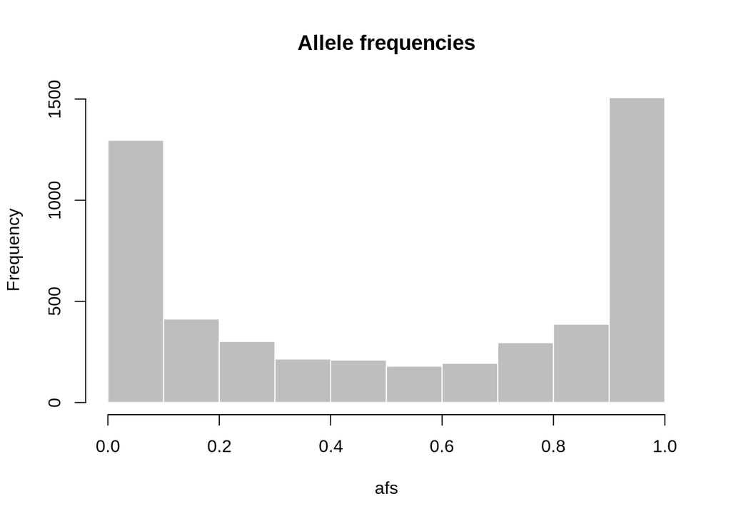

```r
afs <- colMeans(X) / 2
hist(afs, xlim=c(0, 1), main="Allele frequencies", col="grey", border="white")
```

## 4.2 Relations génétiques additives

Estimateur de Habier et coll. (2007):

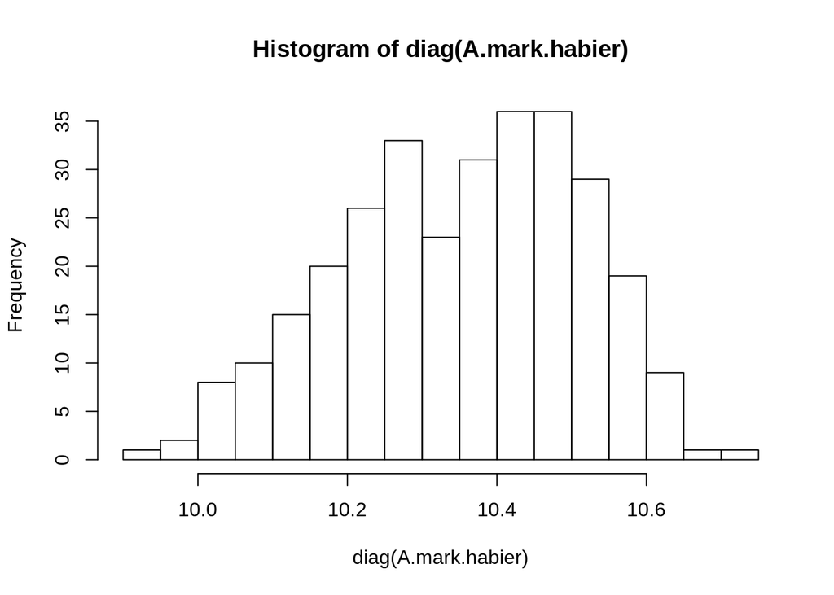

```r
A.mark.habier <- (X %*% t(X)) / (2 * sum(afs * (1 - afs)))
hist(diag(A.mark.habier), breaks="FD")
```

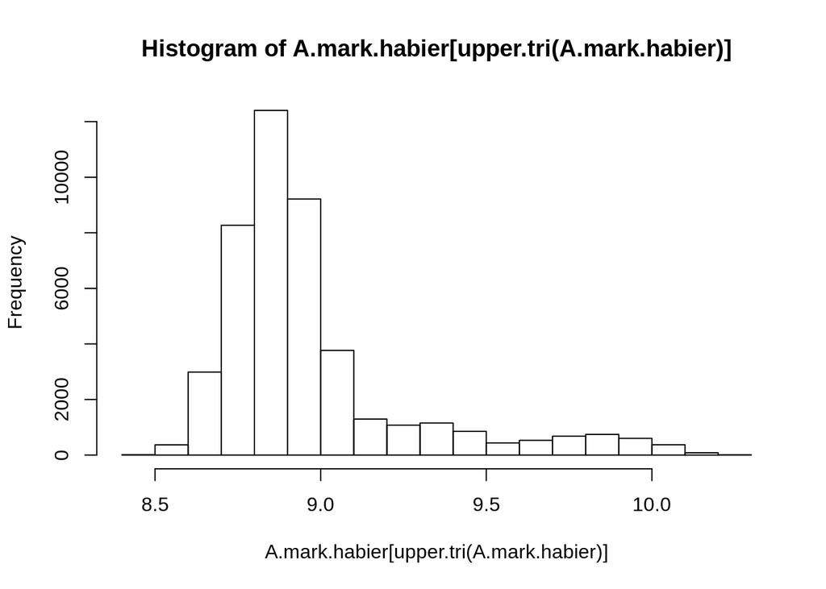

```r
hist(A.mark.habier[upper.tri(A.mark.habier)])
```

Estimateur de VanRaden (2008):

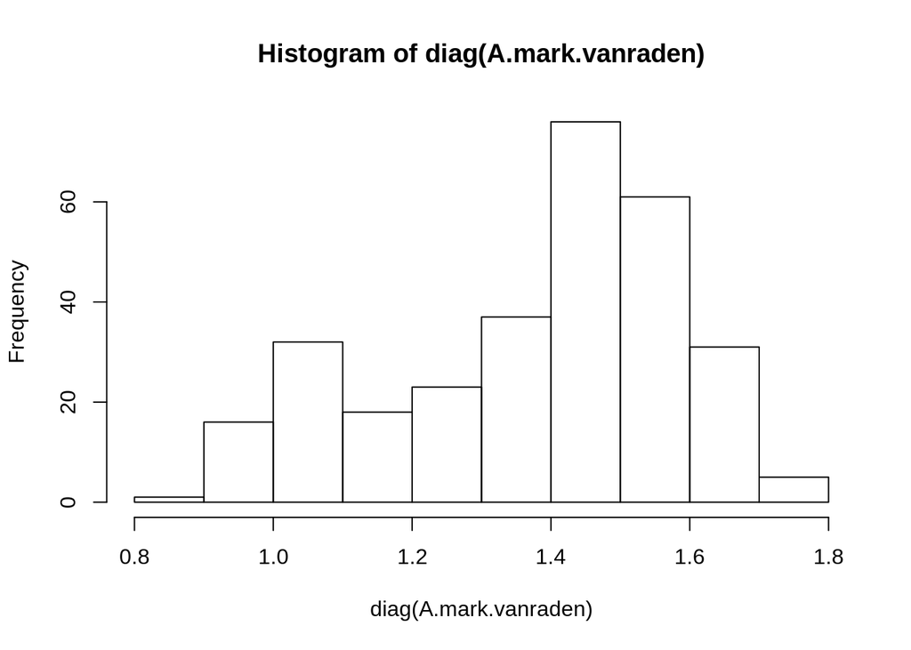

```r
N <- nb.genos # nombre d'individus
tmp <- matrix(rep(1, N)) %*% (2 * afs)
X.center <- X - tmp
A.mark.vanraden <- (X.center %*% t(X.center)) / (2 * sum(afs * (1 - afs)))
hist(diag(A.mark.vanraden), breaks="FD")
```

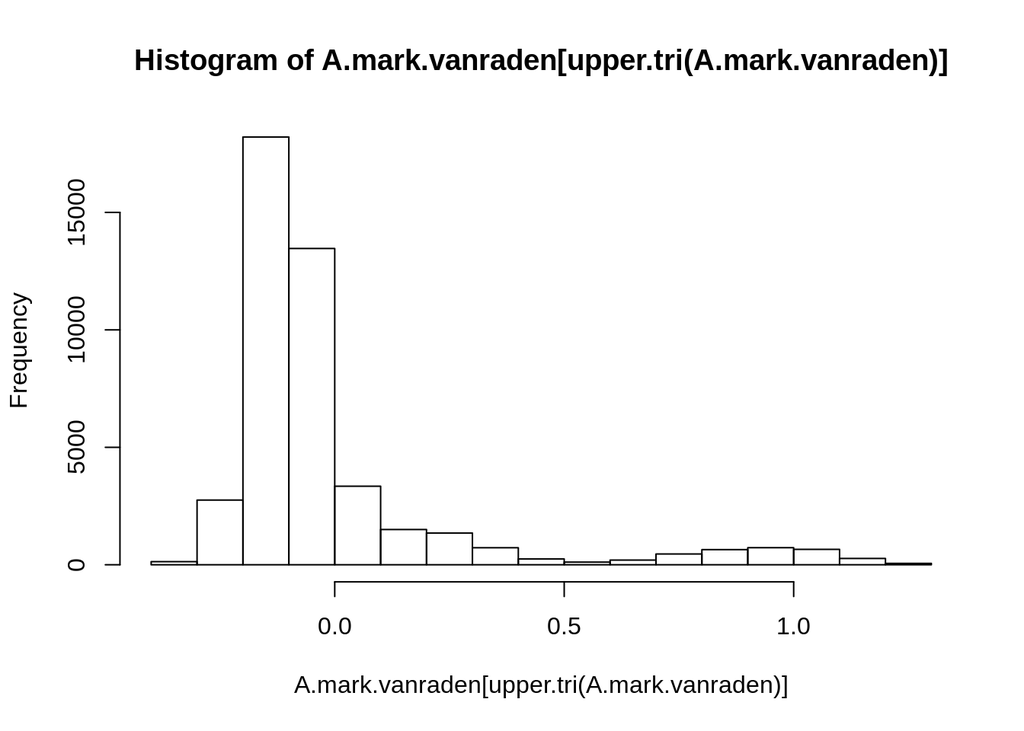

```r
hist(A.mark.vanraden[upper.tri(A.mark.vanraden)])
```

## 4.3 Valeurs génotypiques additives et variance génétique additive

Notez que $X$ est initialement codé en $\{0,1,2\}$, mais que dans la suite on peut le centrer à l’aide des fréquences alléliques comme dans l’estimateur de VanRaden:

```r
X <- X.center
# Effet génétique additif
a <- X %*% beta
# Variance génétique additive
(sigma.a2 <- sigma.beta2 * 2 * sum(afs * (1 - afs)))
```

```
## [1] 0.944
```

## 4.4 Erreurs

```r
h2 <- 0.7 # héritabilité au sens strict
(sigma2 <- ((1 - h2) / h2) * sigma.a2) # variance d'erreur calculée à partir de h^2 et de sigma.a2
```

```
## [1] 0.405
```

```r
epsilon <- rnorm(n=N, mean=0, sd=sqrt(sigma2)) # vecteur d'erreurs
```

## 4.5 Phénotypes

```r
mu <- 36 # chosen arbitrarily
y <- mu + X %*% beta + epsilon
summary(y)
```

```
##        V1
##  Min.   :32.8
##  1st Qu.:35.2
##  Median :35.9
##  Mean   :35.9
##  3rd Qu.:36.7
##  Max.   :39.0
```

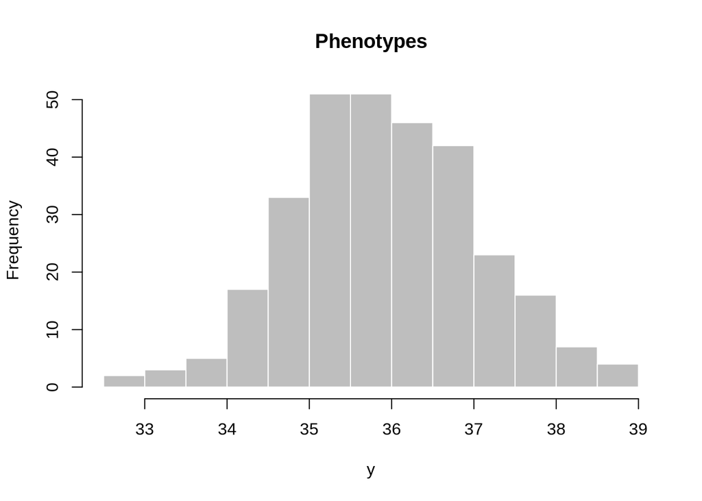

```r
hist(y, breaks="FD", main="Phenotypes", col="grey", border="white")
```

# 5 Distinction des sous-population

```r
if(is.structure){
  sub_pop <- find.clusters(x=X, n.pca=100, scale=TRUE, method="kmeans",
                           choose.n.clust=TRUE, n.clust=6)
  levels(sub_pop$grp)
  sub_pop$size
}
```

```
## [1] 90 30 60 30 60 30
```

# 6 Evaluation de la précision de prédiction

## 6.1 Définition des ensembles d’entraînement et de test

Création de vecteurs logiques (TRUE / FALSE) pour indiquer quels individus sont contenus dans la population d’entrainement et lesquels sont dans la population de validation. Pour l’exemple, on fait ici un ajustement du modèle sur les individus du jeu d’entraînement (`in.train`), on compare les effets estimés avec la simulation et on prédit sur les individus du jeu de validation (`in.test`).

Dans la pratique, on utilise des fonctions de **validation croisée** qui vont, pour chaque partition, estimer directement la qualité de la prédiction sur le jeu de validation.

```r
prop <- 0.8
in.train <- sample(c(TRUE,FALSE), size=N, replace=TRUE, prob=c(prop, 1-prop))
sum(in.train)
```

```
## [1] 237
```

```r
in.test <- (! in.train)
sum(in.test)
```

```
## [1] 63
```

```r
stopifnot(xor(in.train, in.test)) # vérification que chaque individu est soit dans l'ensemble d'entrainement, soit dans l'ensemble de validation
```

### 6.1.1 Entraînement

Ajuster le modèle:

```r
fit <- mixed.solve(y=y[in.train], Z=X[in.train,])
```

Comparer les estimations des paramètres avec les valeurs utilisées pour simuler les données:

```r
# Moyenne
mu.hat <- fit$beta
c(mu, mu.hat)
```

```
## [1] 36.0 35.9
```

```r
# Variance génétique
sigma.beta2.hat <- fit$Vu
c(sigma.beta2, sigma.beta2.hat)
```

```
## [1] 0.001000 0.000658
```

```r
# Variance d'erreur
sigma2.hat <- fit$Ve
c(sigma2, sigma2.hat)
```

```
## [1] 0.405 0.490
```

```r
# Variance génétique additive
sigma.a2.hat <- sigma.beta2.hat * 2 * sum(afs * (1 - afs))
c(sigma.a2, sigma.a2.hat)
```

```
## [1] 0.944 0.622
```

```r
# Héritabilité au sens strict
h2.hat <- sigma.a2.hat / (sigma.a2.hat + sigma2)
c(h2, h2.hat)
```

```
## [1] 0.700 0.606
```

```r
# Effet des marqueurs
beta.hat <- fit$u
# Ici on connait la "vérité", on peut comparer les effets estimés avec les effets simulés
(tmp <- cor(beta, beta.hat))
```

```
## [1] 0.142
```

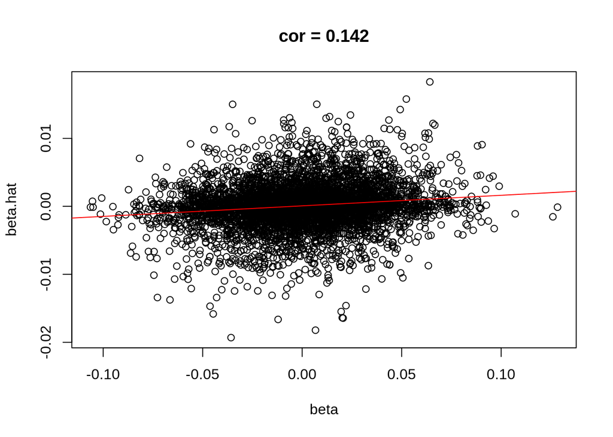

```r
plot(beta, beta.hat, main=paste0("cor = ", round(tmp, 3)))
abline(lm(beta.hat ~ beta), col="red")
```

```r
a.pred.train <- X[in.train,] %*% beta.hat # breeding values pop entrainement = valeurs génotypiques additives
(tmp <- cor(a[in.train], a.pred.train))
```

```
##       [,1]
## [1,] 0.871
```

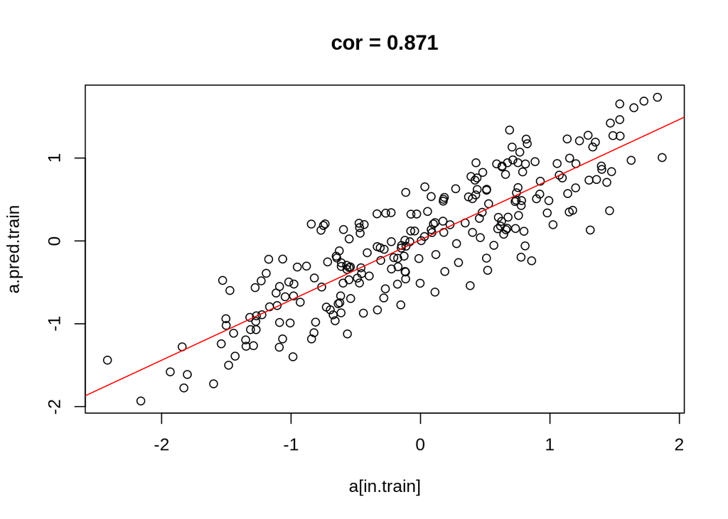

```r
plot(a[in.train], a.pred.train, main=paste0("cor = ", round(tmp, 3)))
abline(lm(a.pred.train ~ a[in.train]), col="red")
```

### 6.1.2 Test

Prédire les valeurs génotypiques sur l’ensemble de test à partir des effets alléliques estimés sur l’ensemble d’entraînement:

```r
a.pred.test <- X[in.test,] %*% beta.hat  # breeding values pop test
(tmp <- cor(a[in.test], a.pred.test)) # précision de prédiction ou predictive ability
```

```
##       [,1]
## [1,] 0.745
```

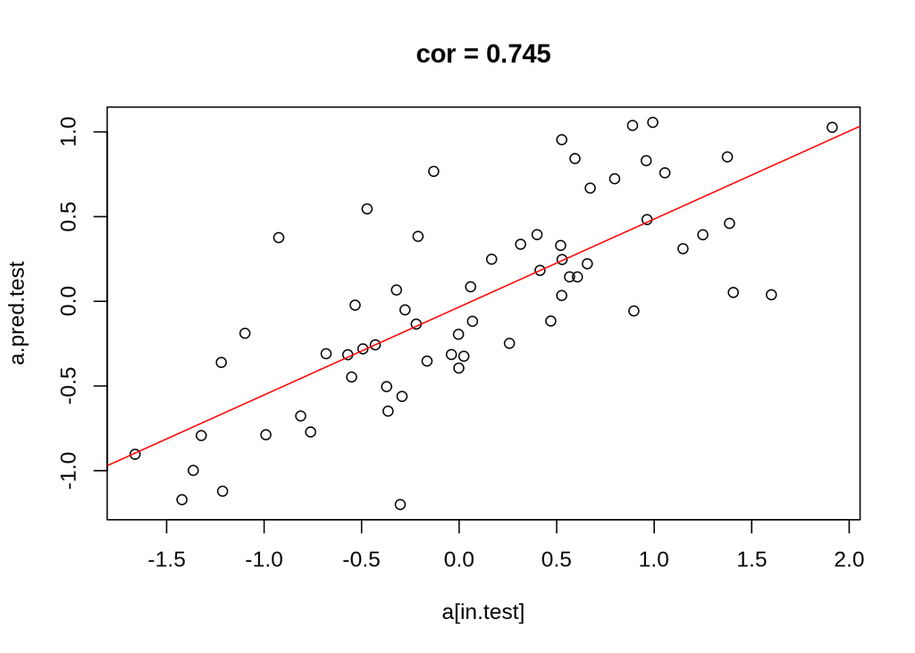

```r
plot(a[in.test], a.pred.test, main=paste0("cor = ", round(tmp, 3)))
abline(lm(a.pred.test ~ a[in.test]), col="red")
```

## 6.2 Validation croisée

En pratique, on définit de façon automatique toutes les partitions pour la validation croisée et on affiche directement les résultats des KxR précisions de prédiction.

### 6.2.1 Fonctions

Définir des fonctions supplémentaires est nécessaire pour utiliser le paquet `cvTools` avec la fonction `mixed.solve` du paquet `rrBLUP`:

```r
rr <- function(y, Z, K=NULL, X=NULL, method="REML"){
  stopifnot(is.matrix(Z))
  out <- rrBLUP::mixed.solve(y=y, Z=Z, K=K, X=X, method=method)
  return(structure(out, class="rr"))
}
predict.rr <- function(object, newZ){
  stopifnot(is.matrix(newZ))
  out <- as.vector(newZ %*% object$u)
  if(! is.null(rownames(newZ)))
    names(out) <- rownames(newZ)
  return(out)
}
```

### 6.2.2 Partitions

La fonction `cvFolds` va permettre de définir les jeux d’entraînement et de validation de la validation croisée.

- K = 5 : nombre de partitions voulues, le jeu d’entraînement comportera alors 4/5e des individus
- R = 10 : nombre de fois que la validation croisée est répétée, à chaque fois on rééchantillonne des individus différents dans les populations d’entraînement et de validation.

```r
folds <- cvFolds(n=nrow(X), K=5, R=10)
dim(folds$subsets)
```

```
## [1] 300  10
```

A la fin nous aurons donc 50 valeurs de précision de prédiction, correspondant à 50 ajustements du modèle, c’est ce que fait la fonction suivante, `cvTool`. La fonction ne renvoie que la moyenne des précision de prédiction par réplicat.

### 6.2.3 Validation

```r
callRR <- call("rr", y=y, Z=X)
system.time(
    out.cv <- cvTool(call=callRR, x=X, y=y, names=c("Z", "y"),
                     cost=cor, folds=folds))
```

```
##    user  system elapsed
##  46.834   0.101  46.988
```

```r
out.cv # one row per replicate
```

```
##          CV
##  [1,] 0.582
##  [2,] 0.593
##  [3,] 0.604
##  [4,] 0.583
##  [5,] 0.614
##  [6,] 0.580
##  [7,] 0.610
##  [8,] 0.596
##  [9,] 0.573
## [10,] 0.569
```

```r
mean(out.cv[,"CV"])
```

```
## [1] 0.591
```

```r
sd(out.cv[,"CV"])
```

```
## [1] 0.0156
```

A vous de jouer ! Modifiez les paramètres par défauts et mesurez leur impact sur la précision de prédiction. Vous choisirez une représentation graphique qui illustrera vos conclusions.

# 7 Annexe

```r
t1 <- proc.time(); t1 - t0
```

```
##    user  system elapsed
##  209.11    3.78  256.41
```